# Erick Medeiros Anastácio

## Data Scientist

### About me

- Data Science Specialist @ [EY](https://www.ey.com/)
- [Microsoft Certified](https://www.youracclaim.com/badges/cbf13782-6b8d-4228-9694-a444544ce78e/linked_in): Azure Data Scientist Associate
- living in São Paulo, Brazil
- [linkedIn](https://www.linkedin.com/in/erick-medeiros-anastácio-15241717/)
- [Github](https://github.com/erickfis)
- in love with:
  - Python
  - Reading
  - Music / Guitar
  - Sports
  - Photography

[figure not shown]

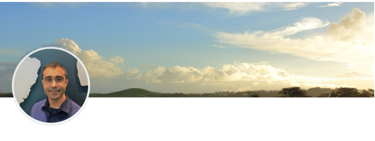

This is me

### Regression

#### AutoOne Price Prediction

Using python + regression models & machine learning, conduct modeling for predicting car prices.

[Full story](https://erickfis.github.io/autoOne_regression/)

### Machine Learning

#### AutoOne Price Prediction

Using python + regression models & machine learning, conduct modeling for predicting car prices.

[Full story](https://erickfis.github.io/autoOne_regression/)

#### Human Activity Recognition

In this project our goal is to predict, through machine learning techniques, if a weight lifiting exercise is being done properly.

We have data from accelerometers put on the belt, forearm, arm, and dumbbell of six young healthy participants who were asked to perform one set of 10 repetitions of the Unilateral Dumbbell Biceps Curl in five different fashions.

Done in R programming language.

[Full report](https://erickfis.github.io/Machine-Learning-for-human-activity-recognition/)

### NLP

#### NLP for topic modeling - building a chat-bot with LDA

Using python + natural language processing for topic modeling through Latent Dirichlet Allocation: a unsupervised technique for document classification.

[Full report](http://nbviewer.jupyter.org/github/erickfis/Python-NLP/blob/master/py-nlp-topics/index.ipynb)

### Neural Networks

Coming soon

### Dashboards

#### NOAA Storm Database - worst cases

Analysis of the NOAA Storm Database, in order to determine what are the worst natural catastrophic events, both in terms of public health and in economic impact.

The U.S. National Oceanic and Atmospheric Administration’s (NOAA) storm database tracks characteristics of major storms and weather events in the United States, including when and where they occur, as well as estimates of any fatalities, injuries, and property damage.

The database currently contains data from January 1950 to January 2017, as entered by NOAA’s National Weather Service (NWS).

Done in R programming language.

[Shinny Dashboard - R](https://erickfis.shinyapps.io/noaa_storm_db_-_economic_losses_-_nvd3/)

#### Management Dashboard for BI

A complete live BI Dashboard that allows managers and stakeholders to quickly track key business metrics (KPIs) and then to take data driven decisions. This app automatically retrieves data from the SQL server so it is always displaying updated information.

Built using Python + Flask + AWS Elastic BeanStalk.

under maintennance

[BI Live Dashboard](http://gerencial.sa-east-1.elasticbeanstalk.com/)

### Descriptive Analysis

#### Analysis of Financial Investments

A descriptive analysis of personal financial investments.

Done in R programming language.

[Full Report](https://erickfis.github.io/personal-financial-investments)

#### NOAA Storm Database - worst cases

Analysis of the NOAA Storm Database, in order to determine what are the worst natural catastrophic events, both in terms of public health and in economic impact.

The U.S. National Oceanic and Atmospheric Administration’s (NOAA) storm database tracks characteristics of major storms and weather events in the United States, including when and where they occur, as well as estimates of any fatalities, injuries, and property damage.

The database currently contains data from January 1950 to January 2017, as entered by NOAA’s National Weather Service (NWS).

Done in R programming language.

[Full Report](https://erickfis.github.io/NOAA-Storm-Database/) | [Pitch presentation](https://erickfis.github.io/NOAA-Storm-Database/slides-picth/) | [Shinny Dashboard - R](https://erickfis.shinyapps.io/noaa_storm_db_-_economic_losses_-_nvd3/)

#### Plataforma Mobills - Análise de Despesas Pessoais

Uma análise descritiva sobre despesas familiares, tendo como base dados coletados através da plataforma mobils.

Feito em linguagem R.

[Relatório completo](https://erickfis.github.io/mobils/)